# Risk Factor Analysis

## Outcome Variable

**Outcome Variable:** ever_stunted

## Predictor Variables

**Intervention Variable:** mbmi

**Adjustment Set:**

unadjusted

## Stratifying Variables

The analysis was stratified on these variable(s):

- agecat
- studyid
- country

## Data Summary

| agecat | studyid | country | A | n | nA | nAY0 | nAY1 |
| --- | --- | --- | --- | --- | --- | --- | --- |
| 3 months | ki0047075b-MAL-ED | BANGLADESH | [18.5-25) | 254 | 163 | 118 | 45 |
| 3 months | ki0047075b-MAL-ED | BANGLADESH | <18.5 | 254 | 32 | 20 | 12 |
| 3 months | ki0047075b-MAL-ED | BANGLADESH | [25-30) | 254 | 53 | 42 | 11 |
| 3 months | ki0047075b-MAL-ED | BANGLADESH | >=30 | 254 | 6 | 2 | 4 |
| 3 months | ki0047075b-MAL-ED | BRAZIL | [18.5-25) | 221 | 88 | 77 | 11 |
| 3 months | ki0047075b-MAL-ED | BRAZIL | <18.5 | 221 | 10 | 7 | 3 |
| 3 months | ki0047075b-MAL-ED | BRAZIL | [25-30) | 221 | 82 | 69 | 13 |
| 3 months | ki0047075b-MAL-ED | BRAZIL | >=30 | 221 | 41 | 34 | 7 |
| 3 months | ki0047075b-MAL-ED | INDIA | [18.5-25) | 242 | 142 | 103 | 39 |
| 3 months | ki0047075b-MAL-ED | INDIA | <18.5 | 242 | 49 | 35 | 14 |
| 3 months | ki0047075b-MAL-ED | INDIA | [25-30) | 242 | 40 | 30 | 10 |
| 3 months | ki0047075b-MAL-ED | INDIA | >=30 | 242 | 11 | 9 | 2 |
| 3 months | ki0047075b-MAL-ED | NEPAL | [18.5-25) | 238 | 134 | 114 | 20 |
| 3 months | ki0047075b-MAL-ED | NEPAL | <18.5 | 238 | 0 | 0 | 0 |
| 3 months | ki0047075b-MAL-ED | NEPAL | [25-30) | 238 | 87 | 74 | 13 |
| 3 months | ki0047075b-MAL-ED | NEPAL | >=30 | 238 | 17 | 13 | 4 |
| 3 months | ki0047075b-MAL-ED | PERU | [18.5-25) | 290 | 159 | 99 | 60 |
| 3 months | ki0047075b-MAL-ED | PERU | <18.5 | 290 | 5 | 3 | 2 |
| 3 months | ki0047075b-MAL-ED | PERU | [25-30) | 290 | 109 | 77 | 32 |
| 3 months | ki0047075b-MAL-ED | PERU | >=30 | 290 | 17 | 11 | 6 |
| 3 months | ki0047075b-MAL-ED | SOUTH AFRICA | [18.5-25) | 270 | 109 | 72 | 37 |
| 3 months | ki0047075b-MAL-ED | SOUTH AFRICA | <18.5 | 270 | 8 | 6 | 2 |
| 3 months | ki0047075b-MAL-ED | SOUTH AFRICA | [25-30) | 270 | 87 | 62 | 25 |
| 3 months | ki0047075b-MAL-ED | SOUTH AFRICA | >=30 | 270 | 66 | 58 | 8 |
| 3 months | ki0047075b-MAL-ED | TANZANIA, UNITED REPUBLIC OF | [18.5-25) | 256 | 177 | 121 | 56 |
| 3 months | ki0047075b-MAL-ED | TANZANIA, UNITED REPUBLIC OF | <18.5 | 256 | 14 | 7 | 7 |
| 3 months | ki0047075b-MAL-ED | TANZANIA, UNITED REPUBLIC OF | [25-30) | 256 | 53 | 37 | 16 |
| 3 months | ki0047075b-MAL-ED | TANZANIA, UNITED REPUBLIC OF | >=30 | 256 | 12 | 10 | 2 |
| 3 months | ki1017093-NIH-Birth | BANGLADESH | [18.5-25) | 629 | 445 | 352 | 93 |
| 3 months | ki1017093-NIH-Birth | BANGLADESH | <18.5 | 629 | 106 | 72 | 34 |

[output cut: 226 more lines]

The following strata were considered:

- agecat: 12 months, studyid: ki0047075b-MAL-ED, country: BANGLADESH
- agecat: 12 months, studyid: ki0047075b-MAL-ED, country: BRAZIL
- agecat: 12 months, studyid: ki0047075b-MAL-ED, country: INDIA
- agecat: 12 months, studyid: ki0047075b-MAL-ED, country: NEPAL
- agecat: 12 months, studyid: ki0047075b-MAL-ED, country: PERU
- agecat: 12 months, studyid: ki0047075b-MAL-ED, country: SOUTH AFRICA
- agecat: 12 months, studyid: ki0047075b-MAL-ED, country: TANZANIA, UNITED REPUBLIC OF
- agecat: 12 months, studyid: ki1017093-NIH-Birth, country: BANGLADESH
- agecat: 12 months, studyid: ki1017093b-PROVIDE, country: BANGLADESH
- agecat: 12 months, studyid: ki1017093c-NIH-Crypto, country: BANGLADESH
- agecat: 12 months, studyid: ki1066203-TanzaniaChild2, country: TANZANIA, UNITED REPUBLIC OF
- agecat: 12 months, studyid: ki1126311-ZVITAMBO, country: ZIMBABWE
- agecat: 12 months, studyid: ki1148112-LCNI-5, country: MALAWI
- agecat: 18 months, studyid: ki0047075b-MAL-ED, country: BANGLADESH
- agecat: 18 months, studyid: ki0047075b-MAL-ED, country: BRAZIL
- agecat: 18 months, studyid: ki0047075b-MAL-ED, country: INDIA
- agecat: 18 months, studyid: ki0047075b-MAL-ED, country: NEPAL
- agecat: 18 months, studyid: ki0047075b-MAL-ED, country: PERU
- agecat: 18 months, studyid: ki0047075b-MAL-ED, country: SOUTH AFRICA
- agecat: 18 months, studyid: ki0047075b-MAL-ED, country: TANZANIA, UNITED REPUBLIC OF
- agecat: 18 months, studyid: ki1017093-NIH-Birth, country: BANGLADESH
- agecat: 18 months, studyid: ki1017093b-PROVIDE, country: BANGLADESH
- agecat: 18 months, studyid: ki1017093c-NIH-Crypto, country: BANGLADESH
- agecat: 18 months, studyid: ki1066203-TanzaniaChild2, country: TANZANIA, UNITED REPUBLIC OF
- agecat: 18 months, studyid: ki1126311-ZVITAMBO, country: ZIMBABWE
- agecat: 18 months, studyid: ki1148112-LCNI-5, country: MALAWI
- agecat: 24 months, studyid: ki0047075b-MAL-ED, country: BANGLADESH
- agecat: 24 months, studyid: ki0047075b-MAL-ED, country: BRAZIL
- agecat: 24 months, studyid: ki0047075b-MAL-ED, country: INDIA
- agecat: 24 months, studyid: ki0047075b-MAL-ED, country: NEPAL
- agecat: 24 months, studyid: ki0047075b-MAL-ED, country: PERU
- agecat: 24 months, studyid: ki0047075b-MAL-ED, country: SOUTH AFRICA
- agecat: 24 months, studyid: ki0047075b-MAL-ED, country: TANZANIA, UNITED REPUBLIC OF
- agecat: 24 months, studyid: ki1017093-NIH-Birth, country: BANGLADESH
- agecat: 24 months, studyid: ki1017093b-PROVIDE, country: BANGLADESH
- agecat: 24 months, studyid: ki1017093c-NIH-Crypto, country: BANGLADESH
- agecat: 24 months, studyid: ki1066203-TanzaniaChild2, country: TANZANIA, UNITED REPUBLIC OF
- agecat: 24 months, studyid: ki1126311-ZVITAMBO, country: ZIMBABWE
- agecat: 24 months, studyid: ki1148112-LCNI-5, country: MALAWI
- agecat: 3 months, studyid: ki0047075b-MAL-ED, country: BANGLADESH
- agecat: 3 months, studyid: ki0047075b-MAL-ED, country: BRAZIL
- agecat: 3 months, studyid: ki0047075b-MAL-ED, country: INDIA
- agecat: 3 months, studyid: ki0047075b-MAL-ED, country: NEPAL
- agecat: 3 months, studyid: ki0047075b-MAL-ED, country: PERU
- agecat: 3 months, studyid: ki0047075b-MAL-ED, country: SOUTH AFRICA
- agecat: 3 months, studyid: ki0047075b-MAL-ED, country: TANZANIA, UNITED REPUBLIC OF
- agecat: 3 months, studyid: ki1017093-NIH-Birth, country: BANGLADESH
- agecat: 3 months, studyid: ki1017093b-PROVIDE, country: BANGLADESH
- agecat: 3 months, studyid: ki1017093c-NIH-Crypto, country: BANGLADESH
- agecat: 3 months, studyid: ki1066203-TanzaniaChild2, country: TANZANIA, UNITED REPUBLIC OF
- agecat: 3 months, studyid: ki1126311-ZVITAMBO, country: ZIMBABWE
- agecat: 6 months, studyid: ki0047075b-MAL-ED, country: BANGLADESH
- agecat: 6 months, studyid: ki0047075b-MAL-ED, country: BRAZIL
- agecat: 6 months, studyid: ki0047075b-MAL-ED, country: INDIA
- agecat: 6 months, studyid: ki0047075b-MAL-ED, country: NEPAL
- agecat: 6 months, studyid: ki0047075b-MAL-ED, country: PERU
- agecat: 6 months, studyid: ki0047075b-MAL-ED, country: SOUTH AFRICA
- agecat: 6 months, studyid: ki0047075b-MAL-ED, country: TANZANIA, UNITED REPUBLIC OF
- agecat: 6 months, studyid: ki1017093-NIH-Birth, country: BANGLADESH
- agecat: 6 months, studyid: ki1017093b-PROVIDE, country: BANGLADESH
- agecat: 6 months, studyid: ki1017093c-NIH-Crypto, country: BANGLADESH
- agecat: 6 months, studyid: ki1066203-TanzaniaChild2, country: TANZANIA, UNITED REPUBLIC OF
- agecat: 6 months, studyid: ki1126311-ZVITAMBO, country: ZIMBABWE
- agecat: 6 months, studyid: ki1148112-LCNI-5, country: MALAWI

### Dropped Strata

Some strata were dropped due to rare outcomes:

- agecat: 3 months, studyid: ki0047075b-MAL-ED, country: BANGLADESH
- agecat: 3 months, studyid: ki0047075b-MAL-ED, country: BRAZIL
- agecat: 3 months, studyid: ki0047075b-MAL-ED, country: INDIA
- agecat: 3 months, studyid: ki0047075b-MAL-ED, country: NEPAL
- agecat: 3 months, studyid: ki0047075b-MAL-ED, country: PERU
- agecat: 3 months, studyid: ki0047075b-MAL-ED, country: SOUTH AFRICA
- agecat: 3 months, studyid: ki0047075b-MAL-ED, country: TANZANIA, UNITED REPUBLIC OF
- agecat: 3 months, studyid: ki1017093-NIH-Birth, country: BANGLADESH
- agecat: 3 months, studyid: ki1017093b-PROVIDE, country: BANGLADESH
- agecat: 3 months, studyid: ki1017093c-NIH-Crypto, country: BANGLADESH
- agecat: 6 months, studyid: ki0047075b-MAL-ED, country: BANGLADESH
- agecat: 6 months, studyid: ki0047075b-MAL-ED, country: BRAZIL
- agecat: 6 months, studyid: ki0047075b-MAL-ED, country: INDIA
- agecat: 6 months, studyid: ki0047075b-MAL-ED, country: NEPAL
- agecat: 6 months, studyid: ki0047075b-MAL-ED, country: PERU
- agecat: 6 months, studyid: ki0047075b-MAL-ED, country: SOUTH AFRICA
- agecat: 6 months, studyid: ki0047075b-MAL-ED, country: TANZANIA, UNITED REPUBLIC OF
- agecat: 6 months, studyid: ki1017093-NIH-Birth, country: BANGLADESH
- agecat: 6 months, studyid: ki1017093b-PROVIDE, country: BANGLADESH
- agecat: 6 months, studyid: ki1148112-LCNI-5, country: MALAWI
- agecat: 12 months, studyid: ki0047075b-MAL-ED, country: BANGLADESH
- agecat: 12 months, studyid: ki0047075b-MAL-ED, country: BRAZIL
- agecat: 12 months, studyid: ki0047075b-MAL-ED, country: INDIA
- agecat: 12 months, studyid: ki0047075b-MAL-ED, country: NEPAL
- agecat: 12 months, studyid: ki0047075b-MAL-ED, country: PERU
- agecat: 12 months, studyid: ki0047075b-MAL-ED, country: SOUTH AFRICA
- agecat: 12 months, studyid: ki0047075b-MAL-ED, country: TANZANIA, UNITED REPUBLIC OF
- agecat: 12 months, studyid: ki1017093b-PROVIDE, country: BANGLADESH
- agecat: 12 months, studyid: ki1148112-LCNI-5, country: MALAWI
- agecat: 18 months, studyid: ki0047075b-MAL-ED, country: BANGLADESH
- agecat: 18 months, studyid: ki0047075b-MAL-ED, country: BRAZIL
- agecat: 18 months, studyid: ki0047075b-MAL-ED, country: INDIA
- agecat: 18 months, studyid: ki0047075b-MAL-ED, country: NEPAL
- agecat: 18 months, studyid: ki0047075b-MAL-ED, country: PERU
- agecat: 18 months, studyid: ki0047075b-MAL-ED, country: SOUTH AFRICA
- agecat: 18 months, studyid: ki0047075b-MAL-ED, country: TANZANIA, UNITED REPUBLIC OF
- agecat: 18 months, studyid: ki1017093-NIH-Birth, country: BANGLADESH
- agecat: 18 months, studyid: ki1148112-LCNI-5, country: MALAWI
- agecat: 24 months, studyid: ki0047075b-MAL-ED, country: BANGLADESH
- agecat: 24 months, studyid: ki0047075b-MAL-ED, country: BRAZIL
- agecat: 24 months, studyid: ki0047075b-MAL-ED, country: INDIA
- agecat: 24 months, studyid: ki0047075b-MAL-ED, country: NEPAL
- agecat: 24 months, studyid: ki0047075b-MAL-ED, country: PERU
- agecat: 24 months, studyid: ki0047075b-MAL-ED, country: SOUTH AFRICA
- agecat: 24 months, studyid: ki0047075b-MAL-ED, country: TANZANIA, UNITED REPUBLIC OF
- agecat: 24 months, studyid: ki1017093-NIH-Birth, country: BANGLADESH
- agecat: 24 months, studyid: ki1066203-TanzaniaChild2, country: TANZANIA, UNITED REPUBLIC OF
- agecat: 24 months, studyid: ki1148112-LCNI-5, country: MALAWI

## Methods Detail

We’re interested in the causal parameters $E[Y_a]$ for all values of $a \in \mathcal{A}$. These parameters represent the mean outcome if, possibly contrary to fact, we intervened to set all units to have $A=a$. Under the randomization and positivity assumptions, these are identified by the statistical parameters $\psi_a=E_W[E_{Y|A,W}(Y|A=a,W)]$. In addition, we’re interested in the mean of $Y$, $E[Y]$ under no intervention (the observed mean). We will estimate these parameters by using SuperLearner to fit the relevant likelihood factors – $E_{Y|A,W}(Y|A=a,W)$ and $p(A=a|W)$, and then updating our likelihood fit using a joint TMLE.

For unadjusted analyses ($W=\{\}$), initial likelihoods were estimated using Lrnr_glm to estimate the simple $E(Y|A)$ and Lrnr_mean to estimate $p(A)$. For adjusted analyses, a small library containing Lrnr_glmnet, Lrnr_xgboost, and Lrnr_mean was used.

Having estimated these parameters, we will then use the delta method to estimate relative risks and attributable risks relative to a prespecified baseline level of $A$.

# Results Detail

## Results Plots

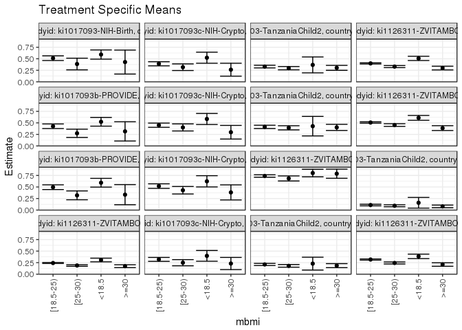

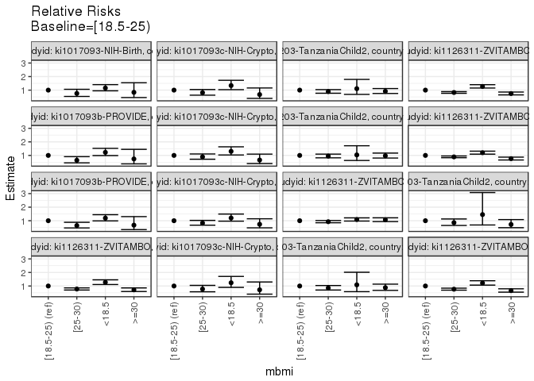

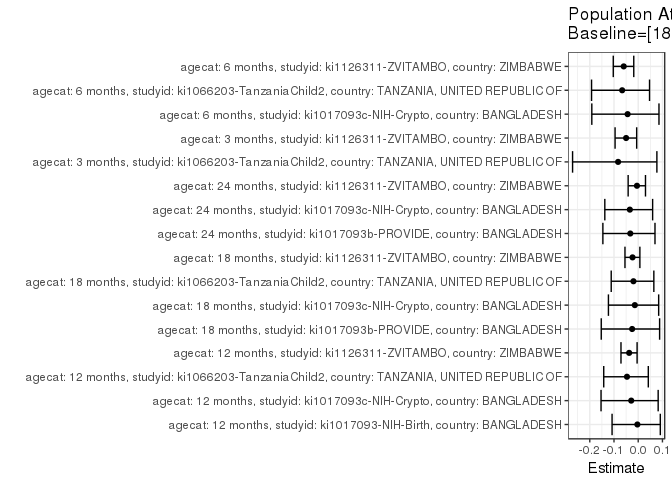

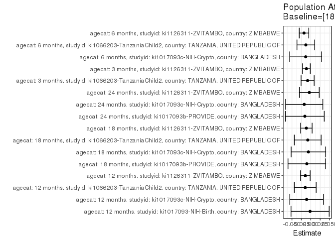

## Results Table

### Parameter: TSM

| agecat | studyid | country | intervention_level | baseline_level | estimate | ci_lower | ci_upper |
| --- | --- | --- | --- | --- | --- | --- | --- |
| 3 months | ki1066203-TanzaniaChild2 | TANZANIA, UNITED REPUBLIC OF | [18.5-25) | NA | 0.1086780 | 0.0913021 | 0.1260539 |
| 3 months | ki1066203-TanzaniaChild2 | TANZANIA, UNITED REPUBLIC OF | <18.5 | NA | 0.1578947 | 0.0419326 | 0.2738568 |
| 3 months | ki1066203-TanzaniaChild2 | TANZANIA, UNITED REPUBLIC OF | [25-30) | NA | 0.0931174 | 0.0721897 | 0.1140452 |
| 3 months | ki1066203-TanzaniaChild2 | TANZANIA, UNITED REPUBLIC OF | >=30 | NA | 0.0787879 | 0.0497146 | 0.1078611 |
| 3 months | ki1126311-ZVITAMBO | ZIMBABWE | [18.5-25) | NA | 0.2418418 | 0.2315965 | 0.2520870 |
| 3 months | ki1126311-ZVITAMBO | ZIMBABWE | <18.5 | NA | 0.3075435 | 0.2677626 | 0.3473244 |
| 3 months | ki1126311-ZVITAMBO | ZIMBABWE | [25-30) | NA | 0.1880342 | 0.1708614 | 0.2052070 |
| 3 months | ki1126311-ZVITAMBO | ZIMBABWE | >=30 | NA | 0.1730104 | 0.1421719 | 0.2038488 |
| 6 months | ki1017093c-NIH-Crypto | BANGLADESH | [18.5-25) | NA | 0.3205128 | 0.2782037 | 0.3628219 |
| 6 months | ki1017093c-NIH-Crypto | BANGLADESH | <18.5 | NA | 0.3970588 | 0.2806854 | 0.5134322 |
| 6 months | ki1017093c-NIH-Crypto | BANGLADESH | [25-30) | NA | 0.2484472 | 0.1816548 | 0.3152396 |
| 6 months | ki1017093c-NIH-Crypto | BANGLADESH | >=30 | NA | 0.2307692 | 0.0984484 | 0.3630901 |
| 6 months | ki1066203-TanzaniaChild2 | TANZANIA, UNITED REPUBLIC OF | [18.5-25) | NA | 0.2106179 | 0.1870360 | 0.2341998 |
| 6 months | ki1066203-TanzaniaChild2 | TANZANIA, UNITED REPUBLIC OF | <18.5 | NA | 0.2285714 | 0.0894250 | 0.3677179 |
| 6 months | ki1066203-TanzaniaChild2 | TANZANIA, UNITED REPUBLIC OF | [25-30) | NA | 0.1798561 | 0.1512958 | 0.2084164 |
| 6 months | ki1066203-TanzaniaChild2 | TANZANIA, UNITED REPUBLIC OF | >=30 | NA | 0.1850649 | 0.1416843 | 0.2284455 |
| 6 months | ki1126311-ZVITAMBO | ZIMBABWE | [18.5-25) | NA | 0.3173298 | 0.3047124 | 0.3299472 |
| 6 months | ki1126311-ZVITAMBO | ZIMBABWE | <18.5 | NA | 0.3860104 | 0.3374409 | 0.4345798 |
| 6 months | ki1126311-ZVITAMBO | ZIMBABWE | [25-30) | NA | 0.2426995 | 0.2212931 | 0.2641060 |
| 6 months | ki1126311-ZVITAMBO | ZIMBABWE | >=30 | NA | 0.2090909 | 0.1710911 | 0.2470907 |
| 12 months | ki1017093-NIH-Birth | BANGLADESH | [18.5-25) | NA | 0.5119363 | 0.4614324 | 0.5624403 |
| 12 months | ki1017093-NIH-Birth | BANGLADESH | <18.5 | NA | 0.5913978 | 0.4913982 | 0.6913975 |
| 12 months | ki1017093-NIH-Birth | BANGLADESH | [25-30) | NA | 0.3859649 | 0.2594671 | 0.5124627 |
| 12 months | ki1017093-NIH-Birth | BANGLADESH | >=30 | NA | 0.4285714 | 0.1691067 | 0.6880362 |
| 12 months | ki1017093c-NIH-Crypto | BANGLADESH | [18.5-25) | NA | 0.3909287 | 0.3464514 | 0.4354060 |
| 12 months | ki1017093c-NIH-Crypto | BANGLADESH | <18.5 | NA | 0.5223881 | 0.4027022 | 0.6420740 |
| 12 months | ki1017093c-NIH-Crypto | BANGLADESH | [25-30) | NA | 0.3167702 | 0.2448603 | 0.3886801 |
| 12 months | ki1017093c-NIH-Crypto | BANGLADESH | >=30 | NA | 0.2631579 | 0.1230541 | 0.4032617 |
| 12 months | ki1066203-TanzaniaChild2 | TANZANIA, UNITED REPUBLIC OF | [18.5-25) | NA | 0.3303660 | 0.3013658 | 0.3593661 |
| 12 months | ki1066203-TanzaniaChild2 | TANZANIA, UNITED REPUBLIC OF | <18.5 | NA | 0.3666667 | 0.1941819 | 0.5391514 |
| 12 months | ki1066203-TanzaniaChild2 | TANZANIA, UNITED REPUBLIC OF | [25-30) | NA | 0.2955272 | 0.2597749 | 0.3312794 |
| 12 months | ki1066203-TanzaniaChild2 | TANZANIA, UNITED REPUBLIC OF | >=30 | NA | 0.3028169 | 0.2493649 | 0.3562689 |
| 12 months | ki1126311-ZVITAMBO | ZIMBABWE | [18.5-25) | NA | 0.3992577 | 0.3864958 | 0.4120195 |
| 12 months | ki1126311-ZVITAMBO | ZIMBABWE | <18.5 | NA | 0.5078652 | 0.4614125 | 0.5543178 |
| 12 months | ki1126311-ZVITAMBO | ZIMBABWE | [25-30) | NA | 0.3297935 | 0.3074107 | 0.3521763 |
| 12 months | ki1126311-ZVITAMBO | ZIMBABWE | >=30 | NA | 0.2981744 | 0.2577913 | 0.3385576 |
| 18 months | ki1017093b-PROVIDE | BANGLADESH | [18.5-25) | NA | 0.4267016 | 0.3770619 | 0.4763413 |
| 18 months | ki1017093b-PROVIDE | BANGLADESH | <18.5 | NA | 0.5233645 | 0.4286510 | 0.6180780 |
| 18 months | ki1017093b-PROVIDE | BANGLADESH | [25-30) | NA | 0.2736842 | 0.1839549 | 0.3634135 |
| 18 months | ki1017093b-PROVIDE | BANGLADESH | >=30 | NA | 0.3157895 | 0.1066069 | 0.5249720 |
| 18 months | ki1017093c-NIH-Crypto | BANGLADESH | [18.5-25) | NA | 0.4495614 | 0.4038717 | 0.4952511 |
| 18 months | ki1017093c-NIH-Crypto | BANGLADESH | <18.5 | NA | 0.5846154 | 0.4647329 | 0.7044978 |
| 18 months | ki1017093c-NIH-Crypto | BANGLADESH | [25-30) | NA | 0.4012739 | 0.3245489 | 0.4779989 |
| 18 months | ki1017093c-NIH-Crypto | BANGLADESH | >=30 | NA | 0.2972973 | 0.1499194 | 0.4446752 |
| 18 months | ki1066203-TanzaniaChild2 | TANZANIA, UNITED REPUBLIC OF | [18.5-25) | NA | 0.4130435 | 0.3774588 | 0.4486281 |
| 18 months | ki1066203-TanzaniaChild2 | TANZANIA, UNITED REPUBLIC OF | <18.5 | NA | 0.4285714 | 0.2168408 | 0.6403021 |
| 18 months | ki1066203-TanzaniaChild2 | TANZANIA, UNITED REPUBLIC OF | [25-30) | NA | 0.3925439 | 0.3477086 | 0.4373791 |
| 18 months | ki1066203-TanzaniaChild2 | TANZANIA, UNITED REPUBLIC OF | >=30 | NA | 0.4019139 | 0.3354209 | 0.4684069 |
| 18 months | ki1126311-ZVITAMBO | ZIMBABWE | [18.5-25) | NA | 0.5073512 | 0.4921374 | 0.5225649 |
| 18 months | ki1126311-ZVITAMBO | ZIMBABWE | <18.5 | NA | 0.6084337 | 0.5559258 | 0.6609417 |
| 18 months | ki1126311-ZVITAMBO | ZIMBABWE | [25-30) | NA | 0.4527145 | 0.4238429 | 0.4815861 |
| 18 months | ki1126311-ZVITAMBO | ZIMBABWE | >=30 | NA | 0.3862275 | 0.3340076 | 0.4384475 |
| 24 months | ki1017093b-PROVIDE | BANGLADESH | [18.5-25) | NA | 0.4959350 | 0.4448769 | 0.5469931 |
| 24 months | ki1017093b-PROVIDE | BANGLADESH | <18.5 | NA | 0.5922330 | 0.4972478 | 0.6872182 |
| 24 months | ki1017093b-PROVIDE | BANGLADESH | [25-30) | NA | 0.3186813 | 0.2228616 | 0.4145010 |
| 24 months | ki1017093b-PROVIDE | BANGLADESH | >=30 | NA | 0.3333333 | 0.1153719 | 0.5512948 |
| 24 months | ki1017093c-NIH-Crypto | BANGLADESH | [18.5-25) | NA | 0.5188917 | 0.4697041 | 0.5680793 |
| 24 months | ki1017093c-NIH-Crypto | BANGLADESH | <18.5 | NA | 0.6229508 | 0.5012337 | 0.7446680 |
| 24 months | ki1017093c-NIH-Crypto | BANGLADESH | [25-30) | NA | 0.4295775 | 0.3480947 | 0.5110602 |
| 24 months | ki1017093c-NIH-Crypto | BANGLADESH | >=30 | NA | 0.3823529 | 0.2188770 | 0.5458289 |
| 24 months | ki1126311-ZVITAMBO | ZIMBABWE | [18.5-25) | NA | 0.7384045 | 0.7121596 | 0.7646493 |
| 24 months | ki1126311-ZVITAMBO | ZIMBABWE | <18.5 | NA | 0.8021978 | 0.7203273 | 0.8840683 |
| 24 months | ki1126311-ZVITAMBO | ZIMBABWE | [25-30) | NA | 0.6847826 | 0.6299525 | 0.7396127 |
| 24 months | ki1126311-ZVITAMBO | ZIMBABWE | >=30 | NA | 0.7878788 | 0.6892187 | 0.8865389 |

### Parameter: E(Y)

| agecat | studyid | country | intervention_level | baseline_level | estimate | ci_lower | ci_upper |
| --- | --- | --- | --- | --- | --- | --- | --- |
| 3 months | ki1066203-TanzaniaChild2 | TANZANIA, UNITED REPUBLIC OF | NA | NA | 0.1003416 | 0.0998099 | 0.1008733 |
| 3 months | ki1126311-ZVITAMBO | ZIMBABWE | NA | NA | 0.2303216 | 0.2297071 | 0.2309361 |
| 6 months | ki1017093c-NIH-Crypto | BANGLADESH | NA | NA | 0.3070652 | 0.3038947 | 0.3102358 |
| 6 months | ki1066203-TanzaniaChild2 | TANZANIA, UNITED REPUBLIC OF | NA | NA | 0.1975309 | 0.1968999 | 0.1981618 |
| 6 months | ki1126311-ZVITAMBO | ZIMBABWE | NA | NA | 0.2994075 | 0.2984727 | 0.3003423 |
| 12 months | ki1017093-NIH-Birth | BANGLADESH | NA | NA | 0.5101664 | 0.5055977 | 0.5147350 |
| 12 months | ki1017093c-NIH-Crypto | BANGLADESH | NA | NA | 0.3799726 | 0.3756544 | 0.3842908 |
| 12 months | ki1066203-TanzaniaChild2 | TANZANIA, UNITED REPUBLIC OF | NA | NA | 0.3157355 | 0.3149589 | 0.3165121 |
| 12 months | ki1126311-ZVITAMBO | ZIMBABWE | NA | NA | 0.3848752 | 0.3839076 | 0.3858427 |
| 18 months | ki1017093b-PROVIDE | BANGLADESH | NA | NA | 0.4162521 | 0.4102608 | 0.4222434 |
| 18 months | ki1017093c-NIH-Crypto | BANGLADESH | NA | NA | 0.4433566 | 0.4391230 | 0.4475903 |
| 18 months | ki1066203-TanzaniaChild2 | TANZANIA, UNITED REPUBLIC OF | NA | NA | 0.4050633 | 0.4045623 | 0.4055643 |
| 18 months | ki1126311-ZVITAMBO | ZIMBABWE | NA | NA | 0.4957193 | 0.4946332 | 0.4968054 |
| 24 months | ki1017093b-PROVIDE | BANGLADESH | NA | NA | 0.4802065 | 0.4733314 | 0.4870817 |
| 24 months | ki1017093c-NIH-Crypto | BANGLADESH | NA | NA | 0.5015773 | 0.4969499 | 0.5062047 |
| 24 months | ki1126311-ZVITAMBO | ZIMBABWE | NA | NA | 0.7346128 | 0.7331313 | 0.7360944 |

### Parameter: RR

| agecat | studyid | country | intervention_level | baseline_level | estimate | ci_lower | ci_upper |
| --- | --- | --- | --- | --- | --- | --- | --- |
| 3 months | ki1066203-TanzaniaChild2 | TANZANIA, UNITED REPUBLIC OF | [18.5-25) | [18.5-25) | 1.0000000 | 1.0000000 | 1.0000000 |
| 3 months | ki1066203-TanzaniaChild2 | TANZANIA, UNITED REPUBLIC OF | <18.5 | [18.5-25) | 1.4528672 | 0.6851692 | 3.0807329 |
| 3 months | ki1066203-TanzaniaChild2 | TANZANIA, UNITED REPUBLIC OF | [25-30) | [18.5-25) | 0.8568191 | 0.6502860 | 1.1289480 |
| 3 months | ki1066203-TanzaniaChild2 | TANZANIA, UNITED REPUBLIC OF | >=30 | [18.5-25) | 0.7249661 | 0.4849131 | 1.0838556 |
| 3 months | ki1126311-ZVITAMBO | ZIMBABWE | [18.5-25) | [18.5-25) | 1.0000000 | 1.0000000 | 1.0000000 |
| 3 months | ki1126311-ZVITAMBO | ZIMBABWE | <18.5 | [18.5-25) | 1.2716726 | 1.1098469 | 1.4570939 |
| 3 months | ki1126311-ZVITAMBO | ZIMBABWE | [25-30) | [18.5-25) | 0.7775092 | 0.7030448 | 0.8598607 |
| 3 months | ki1126311-ZVITAMBO | ZIMBABWE | >=30 | [18.5-25) | 0.7153867 | 0.5956254 | 0.8592282 |
| 6 months | ki1017093c-NIH-Crypto | BANGLADESH | [18.5-25) | [18.5-25) | 1.0000000 | 1.0000000 | 1.0000000 |
| 6 months | ki1017093c-NIH-Crypto | BANGLADESH | <18.5 | [18.5-25) | 1.2388235 | 0.8982727 | 1.7084831 |
| 6 months | ki1017093c-NIH-Crypto | BANGLADESH | [25-30) | [18.5-25) | 0.7751553 | 0.5745368 | 1.0458264 |
| 6 months | ki1017093c-NIH-Crypto | BANGLADESH | >=30 | [18.5-25) | 0.7200000 | 0.3997591 | 1.2967809 |
| 6 months | ki1066203-TanzaniaChild2 | TANZANIA, UNITED REPUBLIC OF | [18.5-25) | [18.5-25) | 1.0000000 | 1.0000000 | 1.0000000 |
| 6 months | ki1066203-TanzaniaChild2 | TANZANIA, UNITED REPUBLIC OF | <18.5 | [18.5-25) | 1.0852420 | 0.5843977 | 2.0153234 |
| 6 months | ki1066203-TanzaniaChild2 | TANZANIA, UNITED REPUBLIC OF | [25-30) | [18.5-25) | 0.8539449 | 0.7031482 | 1.0370815 |
| 6 months | ki1066203-TanzaniaChild2 | TANZANIA, UNITED REPUBLIC OF | >=30 | [18.5-25) | 0.8786761 | 0.6776570 | 1.1393252 |
| 6 months | ki1126311-ZVITAMBO | ZIMBABWE | [18.5-25) | [18.5-25) | 1.0000000 | 1.0000000 | 1.0000000 |
| 6 months | ki1126311-ZVITAMBO | ZIMBABWE | <18.5 | [18.5-25) | 1.2164329 | 1.0660558 | 1.3880221 |
| 6 months | ki1126311-ZVITAMBO | ZIMBABWE | [25-30) | [18.5-25) | 0.7648181 | 0.6942893 | 0.8425115 |
| 6 months | ki1126311-ZVITAMBO | ZIMBABWE | >=30 | [18.5-25) | 0.6589073 | 0.5470532 | 0.7936319 |
| 12 months | ki1017093-NIH-Birth | BANGLADESH | [18.5-25) | [18.5-25) | 1.0000000 | 1.0000000 | 1.0000000 |
| 12 months | ki1017093-NIH-Birth | BANGLADESH | <18.5 | [18.5-25) | 1.1552176 | 0.9498262 | 1.4050230 |
| 12 months | ki1017093-NIH-Birth | BANGLADESH | [25-30) | [18.5-25) | 0.7539315 | 0.5354093 | 1.0616413 |
| 12 months | ki1017093-NIH-Birth | BANGLADESH | >=30 | [18.5-25) | 0.8371577 | 0.4533251 | 1.5459831 |
| 12 months | ki1017093c-NIH-Crypto | BANGLADESH | [18.5-25) | [18.5-25) | 1.0000000 | 1.0000000 | 1.0000000 |
| 12 months | ki1017093c-NIH-Crypto | BANGLADESH | <18.5 | [18.5-25) | 1.3362744 | 1.0346659 | 1.7258028 |
| 12 months | ki1017093c-NIH-Crypto | BANGLADESH | [25-30) | [18.5-25) | 0.8103016 | 0.6285916 | 1.0445395 |
| 12 months | ki1017093c-NIH-Crypto | BANGLADESH | >=30 | [18.5-25) | 0.6731608 | 0.3905550 | 1.1602602 |
| 12 months | ki1066203-TanzaniaChild2 | TANZANIA, UNITED REPUBLIC OF | [18.5-25) | [18.5-25) | 1.0000000 | 1.0000000 | 1.0000000 |
| 12 months | ki1066203-TanzaniaChild2 | TANZANIA, UNITED REPUBLIC OF | <18.5 | [18.5-25) | 1.1098802 | 0.6877836 | 1.7910200 |
| 12 months | ki1066203-TanzaniaChild2 | TANZANIA, UNITED REPUBLIC OF | [25-30) | [18.5-25) | 0.8945448 | 0.7703500 | 1.0387621 |
| 12 months | ki1066203-TanzaniaChild2 | TANZANIA, UNITED REPUBLIC OF | >=30 | [18.5-25) | 0.9166104 | 0.7526078 | 1.1163512 |
| 12 months | ki1126311-ZVITAMBO | ZIMBABWE | [18.5-25) | [18.5-25) | 1.0000000 | 1.0000000 | 1.0000000 |
| 12 months | ki1126311-ZVITAMBO | ZIMBABWE | <18.5 | [18.5-25) | 1.2720235 | 1.1545587 | 1.4014392 |
| 12 months | ki1126311-ZVITAMBO | ZIMBABWE | [25-30) | [18.5-25) | 0.8260167 | 0.7663167 | 0.8903676 |
| 12 months | ki1126311-ZVITAMBO | ZIMBABWE | >=30 | [18.5-25) | 0.7468220 | 0.6498044 | 0.8583247 |
| 18 months | ki1017093b-PROVIDE | BANGLADESH | [18.5-25) | [18.5-25) | 1.0000000 | 1.0000000 | 1.0000000 |
| 18 months | ki1017093b-PROVIDE | BANGLADESH | <18.5 | [18.5-25) | 1.2265352 | 0.9891162 | 1.5209422 |
| 18 months | ki1017093b-PROVIDE | BANGLADESH | [25-30) | [18.5-25) | 0.6413949 | 0.4529404 | 0.9082594 |
| 18 months | ki1017093b-PROVIDE | BANGLADESH | >=30 | [18.5-25) | 0.7400710 | 0.3777366 | 1.4499658 |
| 18 months | ki1017093c-NIH-Crypto | BANGLADESH | [18.5-25) | [18.5-25) | 1.0000000 | 1.0000000 | 1.0000000 |
| 18 months | ki1017093c-NIH-Crypto | BANGLADESH | <18.5 | [18.5-25) | 1.3004128 | 1.0343943 | 1.6348440 |
| 18 months | ki1017093c-NIH-Crypto | BANGLADESH | [25-30) | [18.5-25) | 0.8925897 | 0.7188057 | 1.1083890 |
| 18 months | ki1017093c-NIH-Crypto | BANGLADESH | >=30 | [18.5-25) | 0.6613052 | 0.3986879 | 1.0969096 |
| 18 months | ki1066203-TanzaniaChild2 | TANZANIA, UNITED REPUBLIC OF | [18.5-25) | [18.5-25) | 1.0000000 | 1.0000000 | 1.0000000 |
| 18 months | ki1066203-TanzaniaChild2 | TANZANIA, UNITED REPUBLIC OF | <18.5 | [18.5-25) | 1.0375940 | 0.6283932 | 1.7132606 |
| 18 months | ki1066203-TanzaniaChild2 | TANZANIA, UNITED REPUBLIC OF | [25-30) | [18.5-25) | 0.9503693 | 0.8236823 | 1.0965415 |
| 18 months | ki1066203-TanzaniaChild2 | TANZANIA, UNITED REPUBLIC OF | >=30 | [18.5-25) | 0.9730546 | 0.8074746 | 1.1725884 |
| 18 months | ki1126311-ZVITAMBO | ZIMBABWE | [18.5-25) | [18.5-25) | 1.0000000 | 1.0000000 | 1.0000000 |
| 18 months | ki1126311-ZVITAMBO | ZIMBABWE | <18.5 | [18.5-25) | 1.1992359 | 1.0945280 | 1.3139607 |
| 18 months | ki1126311-ZVITAMBO | ZIMBABWE | [25-30) | [18.5-25) | 0.8923100 | 0.8315914 | 0.9574621 |
| 18 months | ki1126311-ZVITAMBO | ZIMBABWE | >=30 | [18.5-25) | 0.7612627 | 0.6628097 | 0.8743399 |
| 24 months | ki1017093b-PROVIDE | BANGLADESH | [18.5-25) | [18.5-25) | 1.0000000 | 1.0000000 | 1.0000000 |
| 24 months | ki1017093b-PROVIDE | BANGLADESH | <18.5 | [18.5-25) | 1.1941748 | 0.9869561 | 1.4449004 |
| 24 months | ki1017093b-PROVIDE | BANGLADESH | [25-30) | [18.5-25) | 0.6425869 | 0.4676354 | 0.8829913 |
| 24 months | ki1017093b-PROVIDE | BANGLADESH | >=30 | [18.5-25) | 0.6721311 | 0.3467187 | 1.3029590 |
| 24 months | ki1017093c-NIH-Crypto | BANGLADESH | [18.5-25) | [18.5-25) | 1.0000000 | 1.0000000 | 1.0000000 |
| 24 months | ki1017093c-NIH-Crypto | BANGLADESH | <18.5 | [18.5-25) | 1.2005411 | 0.9661884 | 1.4917371 |
| 24 months | ki1017093c-NIH-Crypto | BANGLADESH | [25-30) | [18.5-25) | 0.8278750 | 0.6696889 | 1.0234261 |
| 24 months | ki1017093c-NIH-Crypto | BANGLADESH | >=30 | [18.5-25) | 0.7368646 | 0.4755488 | 1.1417746 |
| 24 months | ki1126311-ZVITAMBO | ZIMBABWE | [18.5-25) | [18.5-25) | 1.0000000 | 1.0000000 | 1.0000000 |
| 24 months | ki1126311-ZVITAMBO | ZIMBABWE | <18.5 | [18.5-25) | 1.0863935 | 0.9751088 | 1.2103786 |
| 24 months | ki1126311-ZVITAMBO | ZIMBABWE | [25-30) | [18.5-25) | 0.9273815 | 0.8495965 | 1.0122881 |
| 24 months | ki1126311-ZVITAMBO | ZIMBABWE | >=30 | [18.5-25) | 1.0670017 | 0.9367710 | 1.2153371 |

### Parameter: PAR

| agecat | studyid | country | intervention_level | baseline_level | estimate | ci_lower | ci_upper |
| --- | --- | --- | --- | --- | --- | --- | --- |
| 3 months | ki1066203-TanzaniaChild2 | TANZANIA, UNITED REPUBLIC OF | [18.5-25) | NA | -0.0083364 | -0.0257205 | 0.0090476 |
| 3 months | ki1126311-ZVITAMBO | ZIMBABWE | [18.5-25) | NA | -0.0115202 | -0.0217838 | -0.0012565 |
| 6 months | ki1017093c-NIH-Crypto | BANGLADESH | [18.5-25) | NA | -0.0134476 | -0.0558753 | 0.0289801 |
| 6 months | ki1066203-TanzaniaChild2 | TANZANIA, UNITED REPUBLIC OF | [18.5-25) | NA | -0.0130871 | -0.0366774 | 0.0105033 |
| 6 months | ki1126311-ZVITAMBO | ZIMBABWE | [18.5-25) | NA | -0.0179223 | -0.0305742 | -0.0052703 |
| 12 months | ki1017093-NIH-Birth | BANGLADESH | [18.5-25) | NA | -0.0017700 | -0.0524802 | 0.0489402 |
| 12 months | ki1017093c-NIH-Crypto | BANGLADESH | [18.5-25) | NA | -0.0109562 | -0.0556426 | 0.0337303 |
| 12 months | ki1066203-TanzaniaChild2 | TANZANIA, UNITED REPUBLIC OF | [18.5-25) | NA | -0.0146305 | -0.0436410 | 0.0143801 |
| 12 months | ki1126311-ZVITAMBO | ZIMBABWE | [18.5-25) | NA | -0.0143825 | -0.0271810 | -0.0015840 |
| 18 months | ki1017093b-PROVIDE | BANGLADESH | [18.5-25) | NA | -0.0104495 | -0.0604495 | 0.0395505 |
| 18 months | ki1017093c-NIH-Crypto | BANGLADESH | [18.5-25) | NA | -0.0062048 | -0.0520902 | 0.0396807 |
| 18 months | ki1066203-TanzaniaChild2 | TANZANIA, UNITED REPUBLIC OF | [18.5-25) | NA | -0.0079802 | -0.0435684 | 0.0276080 |
| 18 months | ki1126311-ZVITAMBO | ZIMBABWE | [18.5-25) | NA | -0.0116318 | -0.0268843 | 0.0036206 |
| 24 months | ki1017093b-PROVIDE | BANGLADESH | [18.5-25) | NA | -0.0157284 | -0.0672473 | 0.0357905 |
| 24 months | ki1017093c-NIH-Crypto | BANGLADESH | [18.5-25) | NA | -0.0173144 | -0.0667192 | 0.0320904 |
| 24 months | ki1126311-ZVITAMBO | ZIMBABWE | [18.5-25) | NA | -0.0037916 | -0.0300783 | 0.0224951 |

### Parameter: PAF

| agecat | studyid | country | intervention_level | baseline_level | estimate | ci_lower | ci_upper |
| --- | --- | --- | --- | --- | --- | --- | --- |
| 3 months | ki1066203-TanzaniaChild2 | TANZANIA, UNITED REPUBLIC OF | [18.5-25) | NA | -0.0830805 | -0.2709713 | 0.0770339 |
| 3 months | ki1126311-ZVITAMBO | ZIMBABWE | [18.5-25) | NA | -0.0500177 | -0.0955476 | -0.0063800 |
| 6 months | ki1017093c-NIH-Crypto | BANGLADESH | [18.5-25) | NA | -0.0437940 | -0.1915675 | 0.0856533 |
| 6 months | ki1066203-TanzaniaChild2 | TANZANIA, UNITED REPUBLIC OF | [18.5-25) | NA | -0.0662533 | -0.1926309 | 0.0467327 |
| 6 months | ki1126311-ZVITAMBO | ZIMBABWE | [18.5-25) | NA | -0.0598591 | -0.1029843 | -0.0184200 |
| 12 months | ki1017093-NIH-Birth | BANGLADESH | [18.5-25) | NA | -0.0034694 | -0.1079615 | 0.0911680 |
| 12 months | ki1017093c-NIH-Crypto | BANGLADESH | [18.5-25) | NA | -0.0288341 | -0.1534597 | 0.0823263 |
| 12 months | ki1066203-TanzaniaChild2 | TANZANIA, UNITED REPUBLIC OF | [18.5-25) | NA | -0.0463377 | -0.1423785 | 0.0416289 |
| 12 months | ki1126311-ZVITAMBO | ZIMBABWE | [18.5-25) | NA | -0.0373693 | -0.0711691 | -0.0046361 |
| 18 months | ki1017093b-PROVIDE | BANGLADESH | [18.5-25) | NA | -0.0251038 | -0.1525933 | 0.0882840 |
| 18 months | ki1017093c-NIH-Crypto | BANGLADESH | [18.5-25) | NA | -0.0139950 | -0.1229704 | 0.0844053 |
| 18 months | ki1066203-TanzaniaChild2 | TANZANIA, UNITED REPUBLIC OF | [18.5-25) | NA | -0.0197011 | -0.1114559 | 0.0644790 |
| 18 months | ki1126311-ZVITAMBO | ZIMBABWE | [18.5-25) | NA | -0.0234646 | -0.0547039 | 0.0068495 |
| 24 months | ki1017093b-PROVIDE | BANGLADESH | [18.5-25) | NA | -0.0327534 | -0.1458795 | 0.0692043 |
| 24 months | ki1017093c-NIH-Crypto | BANGLADESH | [18.5-25) | NA | -0.0345199 | -0.1378936 | 0.0594627 |
| 24 months | ki1126311-ZVITAMBO | ZIMBABWE | [18.5-25) | NA | -0.0051614 | -0.0415896 | 0.0299928 |